# Phân tích Dự báo Nhu cầu & Tối ưu hóa Tồn kho — Phase 2

## Bước 3: EDA — Phân tích Nhu cầu theo Thời gian

Xác định Top 3 Category và Top 5 Products theo tổng số lượng đặt hàng, sau đó vẽ biểu đồ xu hướng nhu cầu theo tháng.

```python
# Top 3 Category theo tổng số lượng đặt hàng
top_categories = (df_clean.groupby('Category Name')['Order Item Quantity']
                  .sum().nlargest(3).index.tolist())
print('Top 3 Category:', top_categories)

# Top 5 sản phẩm theo tổng số lượng
top_products = (df_clean.groupby('Product Name')['Order Item Quantity']
                .sum().nlargest(5).index.tolist())
print('Top 5 Products:', top_products)
```

```
Top 3 Category: ['Cleats', "Women's Apparel", 'Indoor/Outdoor Games']
Top 5 Products: ['Perfect Fitness Perfect Rip Deck', "Nike Men's Dri-FIT Victory Golf Polo", "O'Brien Men's Neoprene Life Vest", "Nike Men's Free 5.0+ Running Shoe", "Under Armour Girls' Toddler Spine Surge Runni"]
```

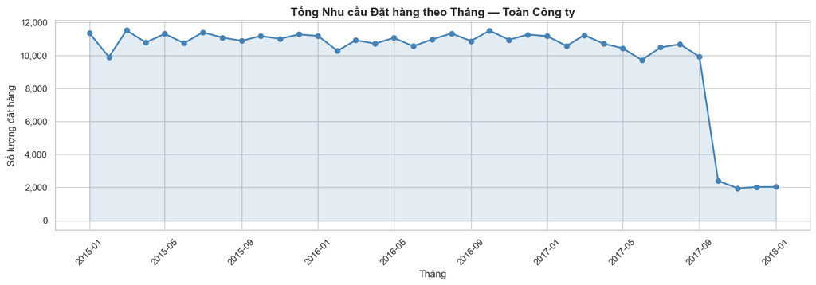

```python
# Biểu đồ tổng nhu cầu toàn công ty theo tháng
monthly_total = (df_clean.groupby('YearMonth')['Order Item Quantity']
                 .sum().reset_index())
monthly_total['YearMonth_dt'] = monthly_total['YearMonth'].dt.to_timestamp()

fig, ax = plt.subplots(figsize=(14, 5))
ax.plot(monthly_total['YearMonth_dt'], monthly_total['Order Item Quantity'],
        marker='o', linewidth=2, color='steelblue')
ax.fill_between(monthly_total['YearMonth_dt'], monthly_total['Order Item Quantity'],
                alpha=0.15, color='steelblue')
ax.set_title('Tổng Nhu cầu Đặt hàng theo Tháng — Toàn Công ty', fontsize=14, fontweight='bold')
ax.set_xlabel('Tháng')
ax.set_ylabel('Số lượng đặt hàng')
ax.yaxis.set_major_formatter(mticker.FuncFormatter(lambda x, _: f'{x:,.0f}'))
plt.xticks(rotation=45)
plt.tight_layout()
plt.show()
```

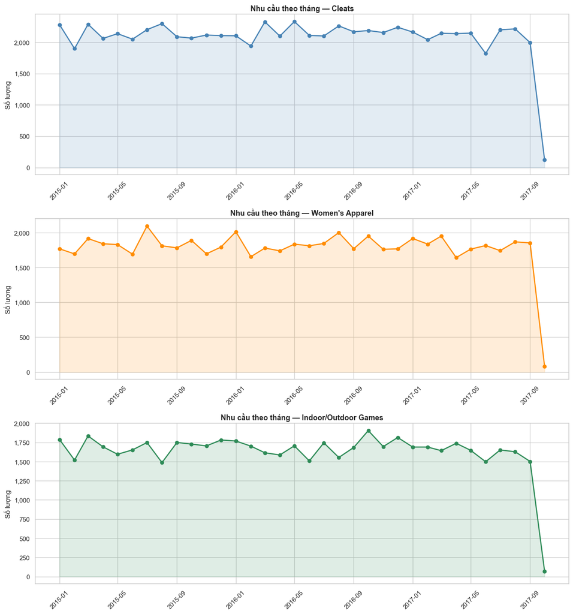

```python
# Biểu đồ nhu cầu theo tháng cho Top 3 Category
fig, axes = plt.subplots(len(top_categories), 1, figsize=(14, 5 * len(top_categories)))
if len(top_categories) == 1:
    axes = [axes]

palette = ['steelblue', 'darkorange', 'seagreen']
for ax, cat, color in zip(axes, top_categories, palette):
    cat_monthly = (df_clean[df_clean['Category Name'] == cat]
                   .groupby('YearMonth')['Order Item Quantity']
                   .sum().reset_index())
    cat_monthly['YearMonth_dt'] = cat_monthly['YearMonth'].dt.to_timestamp()

    ax.plot(cat_monthly['YearMonth_dt'], cat_monthly['Order Item Quantity'],
            marker='o', linewidth=2, color=color)
    ax.fill_between(cat_monthly['YearMonth_dt'], cat_monthly['Order Item Quantity'],
                    alpha=0.15, color=color)
    ax.set_title(f'Nhu cầu theo tháng — {cat}', fontsize=13, fontweight='bold')
    ax.set_ylabel('Số lượng')
    ax.yaxis.set_major_formatter(mticker.FuncFormatter(lambda x, _: f'{x:,.0f}'))
    plt.setp(ax.xaxis.get_majorticklabels(), rotation=45)

plt.tight_layout()
plt.show()
```

## Bước 4: Phân tách Mùa vụ (Seasonal Decomposition)

Tách chuỗi nhu cầu thành 3 thành phần:

- **Trend**: Xu hướng dài hạn (tăng/giảm)
- **Seasonality**: Biến động chu kỳ 12 tháng (mùa vụ)
- **Residual**: Nhiễu ngẫu nhiên còn lại

Dùng `seasonal_decompose` với `model='additive'` (phù hợp khi biên độ mùa vụ không đổi theo thời gian).

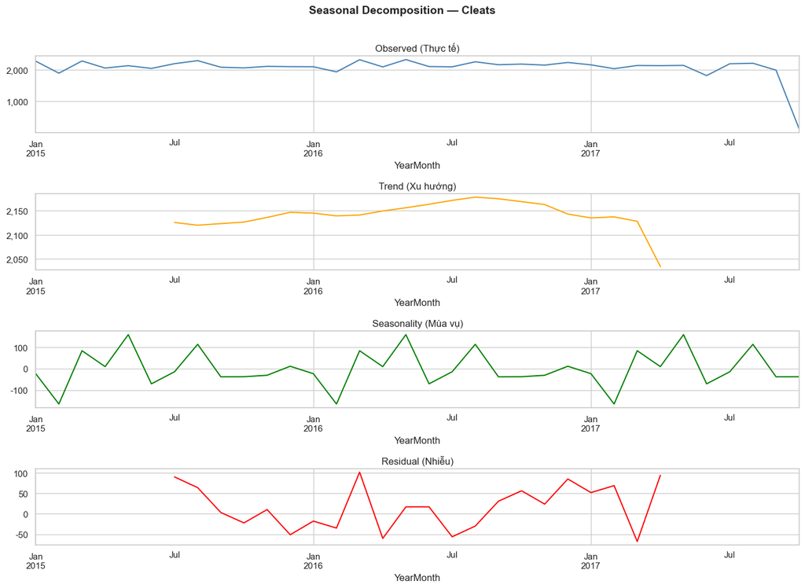

```
  [Cleats] Tháng cao điểm: Tháng 5  |  Tháng thấp điểm: Tháng 2
```

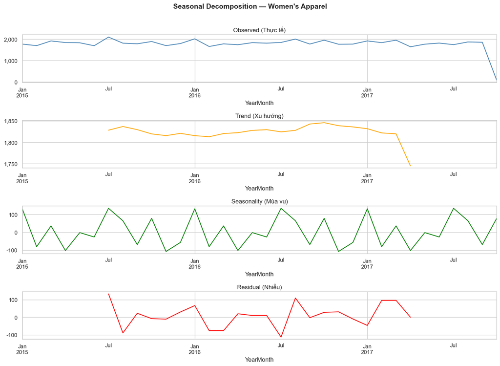

```
  [Women's Apparel] Tháng cao điểm: Tháng 7  |  Tháng thấp điểm: Tháng 11
```

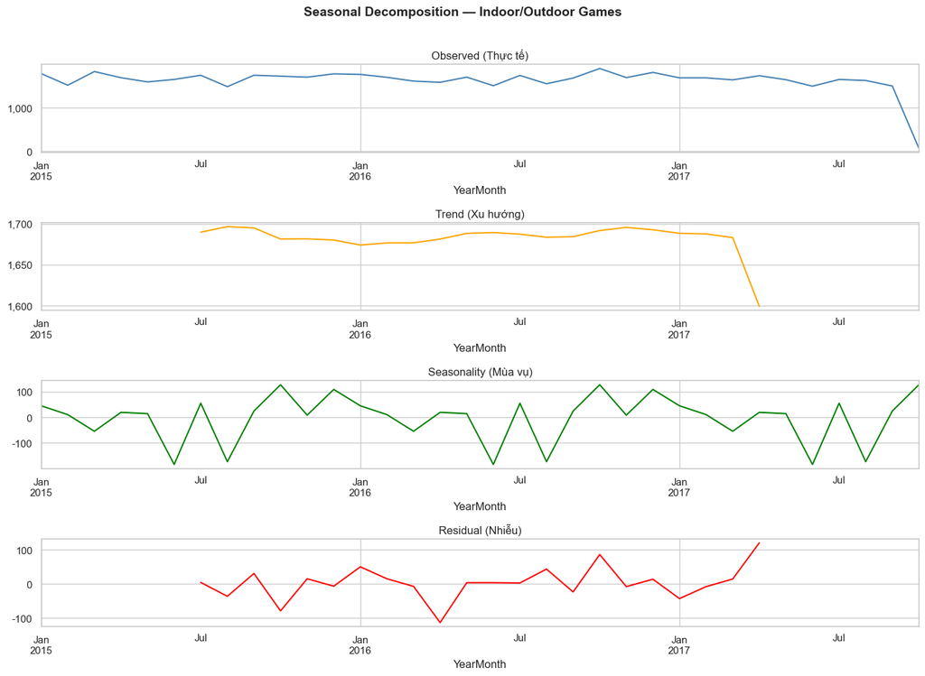

```
  [Indoor/Outdoor Games] Tháng cao điểm: Tháng 10  |  Tháng thấp điểm: Tháng 6
```

```python
for cat in top_categories:
    cat_monthly = (df_clean[df_clean['Category Name'] == cat]
                   .groupby('YearMonth')['Order Item Quantity']
                   .sum())
    cat_monthly.index = cat_monthly.index.to_timestamp()
    cat_monthly = cat_monthly.asfreq('MS').fillna(0)

    if len(cat_monthly) < 24:
        print(f'[SKIP] {cat}: không đủ dữ liệu (cần >=24 tháng, có {len(cat_monthly)})')
        continue

    result = seasonal_decompose(cat_monthly, model='additive', period=12)

    fig, axes = plt.subplots(4, 1, figsize=(14, 10))
    result.observed.plot(ax=axes[0], title='Observed (Thực tế)', color='steelblue')
    result.trend.plot(ax=axes[1], title='Trend (Xu hướng)', color='orange')
    result.seasonal.plot(ax=axes[2], title='Seasonality (Mùa vụ)', color='green')
    result.resid.plot(ax=axes[3], title='Residual (Nhiễu)', color='red')
    for a in axes:
        a.yaxis.set_major_formatter(mticker.FuncFormatter(lambda x, _: f'{x:,.0f}'))
    plt.suptitle(f'Seasonal Decomposition — {cat}', fontsize=14, fontweight='bold', y=1.01)
    plt.tight_layout()
    plt.show()

    # Tháng cao điểm
    seasonal_df = result.seasonal.reset_index()
    seasonal_df.columns = ['Date', 'Seasonal']
    seasonal_df['Month'] = seasonal_df['Date'].dt.month
    monthly_season = seasonal_df.groupby('Month')['Seasonal'].mean()
    peak_month = monthly_season.idxmax()
    low_month  = monthly_season.idxmin()
    print(f'  [{cat}] Tháng cao điểm: Tháng {peak_month}  |  Tháng thấp điểm: Tháng {low_month}')
```

## Bước 5: Dự báo Nhu cầu (Demand Forecasting)

**Ngắn hạn (3 tháng)**: Moving Average 3 tháng (MA3) × Seasonal Index — phù hợp vận hành.

**Dài hạn (12 tháng)**: Linear Regression trên trend × Seasonal Index — phù hợp lập kế hoạch.

Áp dụng cho **Top 3 Category**, sau đó **drill-down** vào **Top 5 Products**.

```python
def forecast_category(df_input, category, forecast_months_short=3, forecast_months_long=12):
    cat_data = (df_input[df_input['Category Name'] == category]
                .groupby('YearMonth')['Order Item Quantity']
                .sum())
    cat_data.index = cat_data.index.to_timestamp()
    cat_data = cat_data.asfreq('MS').fillna(0)

    # --- Moving Average 3 tháng ---
    ma3 = cat_data.rolling(window=3).mean()
    last_3_avg = cat_data[-3:].mean()

    # Seasonal index: tỉ lệ tháng so với trung bình năm
    seasonal_idx = cat_data.groupby(cat_data.index.month).mean() / cat_data.mean()

    last_date = cat_data.index[-1]
    short_dates = pd.date_range(start=last_date + pd.offsets.MonthBegin(1),
                                periods=forecast_months_short, freq='MS')
    short_forecast = pd.Series(
        [last_3_avg * seasonal_idx.get(d.month, 1) for d in short_dates],
        index=short_dates
    )

    # --- Linear Regression dài hạn ---
    X = np.arange(len(cat_data)).reshape(-1, 1)
    y = cat_data.values
    model = LinearRegression().fit(X, y)

    long_X = np.arange(len(cat_data), len(cat_data) + forecast_months_long).reshape(-1, 1)
    long_dates = pd.date_range(start=last_date + pd.offsets.MonthBegin(1),
                               periods=forecast_months_long, freq='MS')
    long_base = model.predict(long_X)
    long_forecast = pd.Series(
        [max(0, long_base[i] * seasonal_idx.get(d.month, 1)) for i, d in enumerate(long_dates)],
        index=long_dates
    )

    return {
        'series': cat_data, 'ma3': ma3,
        'short_forecast': short_forecast,
        'long_forecast': long_forecast,
        'seasonal_idx': seasonal_idx, 'model': model
    }

print('✅ Hàm forecast_category() đã sẵn sàng.')
```

```
✅ Hàm forecast_category() đã sẵn sàng.
```

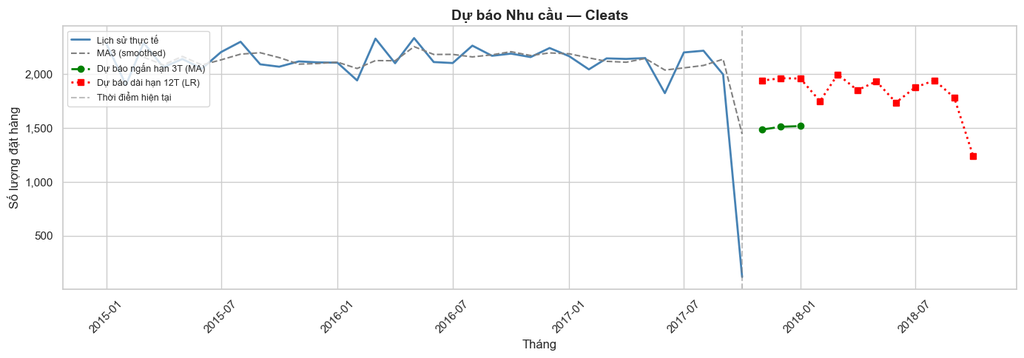

```
[Cleats] Dự báo ngắn hạn (MA3 × Seasonal):
  2017-11: 1,484 đơn vị
  2017-12: 1,511 đơn vị
  2018-01: 1,517 đơn vị
[Cleats] Dự báo dài hạn (12 tháng - LR):
  2017-11: 1,938 đơn vị
  2017-12: 1,960 đơn vị
  2018-01: 1,957 đơn vị
  2018-02: 1,747 đơn vị
  2018-03: 1,996 đơn vị
  2018-04: 1,850 đơn vị
  2018-05: 1,931 đơn vị
  2018-06: 1,735 đơn vị
  2018-07: 1,874 đơn vị
  2018-08: 1,941 đơn vị
  2018-09: 1,780 đơn vị
  2018-10: 1,238 đơn vị
```

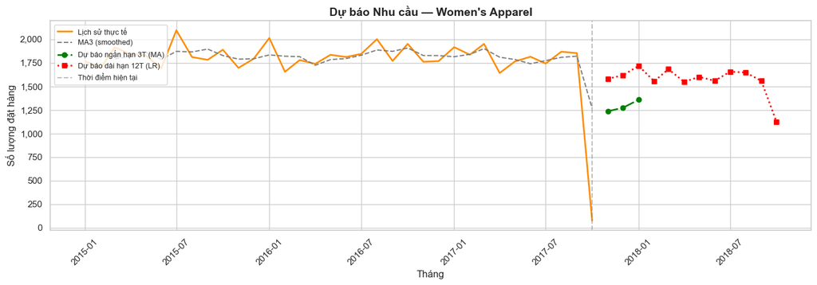

```
[Women's Apparel] Dự báo ngắn hạn (MA3 × Seasonal):
  2017-11: 1,237 đơn vị
  2017-12: 1,274 đơn vị
  2018-01: 1,359 đơn vị
[Women's Apparel] Dự báo dài hạn (12 tháng - LR):
  2017-11: 1,581 đơn vị
  2017-12: 1,620 đơn vị
  2018-01: 1,718 đơn vị
  2018-02: 1,556 đơn vị
  2018-03: 1,684 đơn vị
  2018-04: 1,549 đơn vị
  2018-05: 1,602 đơn vị
  2018-06: 1,560 đơn vị
  2018-07: 1,658 đơn vị
  2018-08: 1,648 đơn vị
  2018-09: 1,559 đơn vị
  2018-10: 1,124 đơn vị
```

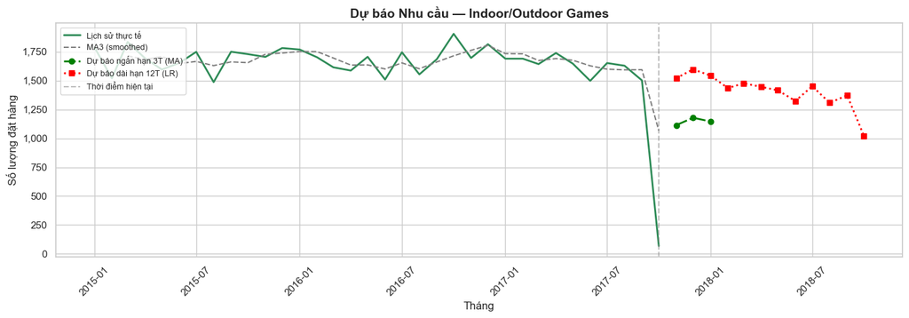

```
[Indoor/Outdoor Games] Dự báo ngắn hạn (MA3 × Seasonal):
  2017-11: 1,114 đơn vị
  2017-12: 1,178 đơn vị
  2018-01: 1,146 đơn vị
[Indoor/Outdoor Games] Dự báo dài hạn (12 tháng - LR):
  2017-11: 1,521 đơn vị
  2017-12: 1,598 đơn vị
  2018-01: 1,543 đơn vị
  2018-02: 1,435 đơn vị
  2018-03: 1,477 đơn vị
  2018-04: 1,446 đơn vị
  2018-05: 1,416 đơn vị
  2018-06: 1,324 đơn vị
  2018-07: 1,451 đơn vị
  2018-08: 1,308 đơn vị
  2018-09: 1,373 đơn vị
  2018-10: 1,022 đơn vị
```

```python
forecast_results = {}
palette = ['steelblue', 'darkorange', 'seagreen']

for cat, color in zip(top_categories, palette):
    res = forecast_category(df_clean, cat)
    forecast_results[cat] = res

    fig, ax = plt.subplots(figsize=(14, 5))
    ax.plot(res['series'].index, res['series'].values,
            label='Lịch sử thực tế', color=color, linewidth=2)
    ax.plot(res['ma3'].index, res['ma3'].values,
            label='MA3 (smoothed)', color='gray', linestyle='--', linewidth=1.5)
    ax.plot(res['short_forecast'].index, res['short_forecast'].values,
            label='Dự báo ngắn hạn 3T (MA)', color='green',
            marker='o', linewidth=2, linestyle='-.')
    ax.plot(res['long_forecast'].index, res['long_forecast'].values,
            label='Dự báo dài hạn 12T (LR)', color='red',
            marker='s', linewidth=2, linestyle=':')
    ax.axvline(x=res['series'].index[-1], color='gray', linestyle='--',
               alpha=0.5, label='Thời điểm hiện tại')
    ax.set_title(f'Dự báo Nhu cầu — {cat}', fontsize=14, fontweight='bold')
    ax.set_xlabel('Tháng')
    ax.set_ylabel('Số lượng đặt hàng')
    ax.yaxis.set_major_formatter(mticker.FuncFormatter(lambda x, _: f'{x:,.0f}'))
    ax.legend(loc='upper left', fontsize=9)
    plt.xticks(rotation=45)
    plt.tight_layout()
    plt.show()

    print(f'\n[{cat}] Dự báo ngắn hạn (MA3 × Seasonal):')
    for d, v in res['short_forecast'].items():
        print(f'  {d.strftime("%Y-%m")}: {v:,.0f} đơn vị')
    print(f'[{cat}] Dự báo dài hạn (12 tháng - LR):')
    for d, v in res['long_forecast'].items():
        print(f'  {d.strftime("%Y-%m")}: {v:,.0f} đơn vị')
```

### Drill-down: Dự báo Top 5 Sản phẩm

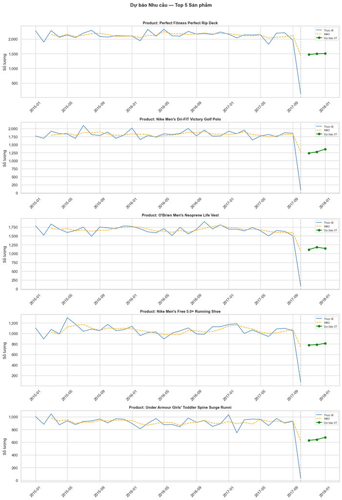

```python
def forecast_product(df_input, product_name, forecast_months=3):
    prod_data = (df_input[df_input['Product Name'] == product_name]
                 .groupby('YearMonth')['Order Item Quantity']
                 .sum())
    prod_data.index = prod_data.index.to_timestamp()
    prod_data = prod_data.asfreq('MS').fillna(0)
    ma3 = prod_data.rolling(window=3).mean()
    last_3_avg = prod_data[-3:].mean()
    last_date  = prod_data.index[-1]
    forecast_dates = pd.date_range(start=last_date + pd.offsets.MonthBegin(1),
                                   periods=forecast_months, freq='MS')
    seasonal_idx = prod_data.groupby(prod_data.index.month).mean() / prod_data.mean()
    fc_vals = pd.Series(
        [last_3_avg * seasonal_idx.get(d.month, 1) for d in forecast_dates],
        index=forecast_dates
    )
    return prod_data, ma3, fc_vals

fig, axes = plt.subplots(len(top_products), 1, figsize=(14, 4 * len(top_products)))
if len(top_products) == 1:
    axes = [axes]

for ax, prod in zip(axes, top_products):
    series, ma3, fc = forecast_product(df_clean, prod)
    ax.plot(series.index, series.values, label='Thực tế', color='steelblue', linewidth=1.5)
    ax.plot(ma3.index,    ma3.values,    label='MA3',     color='orange', linestyle='--')
    ax.plot(fc.index,     fc.values,     label='Dự báo 3T', color='green', marker='o', linewidth=2)
    ax.axvline(x=series.index[-1], color='gray', linestyle='--', alpha=0.5)
    ax.set_title(f'Product: {prod}', fontsize=11, fontweight='bold')
    ax.set_ylabel('Số lượng')
    ax.legend(fontsize=8)
    ax.yaxis.set_major_formatter(mticker.FuncFormatter(lambda x, _: f'{x:,.0f}'))
    plt.setp(ax.xaxis.get_majorticklabels(), rotation=45)

plt.suptitle('Dự báo Nhu cầu — Top 5 Sản phẩm', fontsize=14, fontweight='bold', y=1.01)
plt.tight_layout()
plt.show()
```